# Chapter 1

Marjorie Blanco

12/19/2018

## 0.1 C1-WAGE1

A data.frame with 526 observations on 24 variables:

- wage: average hourly earnings
- educ: years of education
- exper: years potential experience
- tenure: years with current employer
- nonwhite: =1 if nonwhite
- female: =1 if female
- married: =1 if married
- numdep: number of dependents
- smsa: =1 if live in SMSA
- northcen: =1 if live in north central U.S
- south: =1 if live in southern region
- west: =1 if live in western region
- construc: =1 if work in construc. indus.
- ndurman: =1 if in nondur. manuf. indus.
- trcommpu: =1 if in trans, commun, pub ut
- trade: =1 if in wholesale or retail
- services: =1 if in services indus.
- profserv: =1 if in prof. serv. indus.
- profocc: =1 if in profess. occupation
- clerocc: =1 if in clerical occupation
- servocc: =1 if in service occupation
- lwage: log(wage)
- expersq: exper^2
- tenursq: tenure^2
1. Average education level (years)

```
## [1] 12.56274
```

1. Lowest education level (years)

```
## [1] 0
```

- Highest education level (years)

```
## [1] 18
```

- Average hourly wage

```
## [1] 5.896103
```

- Women

```
## [1] 252
```

- Men

```
## [1] 274
```

## 0.2 C2-BWGHT

A data.frame with 1388 observations on 14 variables:

- faminc: 1988 family income, $1000s
- cigtax: cig. tax in home state, 1988
- cigprice: cig. price in home state, 1988
- bwght: birth weight, ounces
- fatheduc: father’s yrs of educ
- motheduc: mother’s yrs of educ
- parity: birth order of child
- male: =1 if male child
- white: =1 if white
- cigs: cigs smked per day while preg
- lbwght: log of bwght
- bwghtlbs: birth weight, pounds
- packs: packs smked per day while preg
- lfaminc: log(faminc)
- Women

```
## [1] 665
```

- Men

```
## [1] 723
```

```
## # A tibble: 4 x 3
## # Groups:   male [2]
##    male smoke     n
##   <int> <dbl> <int>
## 1     0     0   553
## 2     0     1   112
## 3     1     0   623
## 4     1     1   100
```

- Average number of cigarettes smoked per day (All)

```
##       cigs
##  Min.   : 1.00
##  1st Qu.: 8.00
##  Median :10.00
##  Mean   :13.67
##  3rd Qu.:20.00
##  Max.   :50.00
```

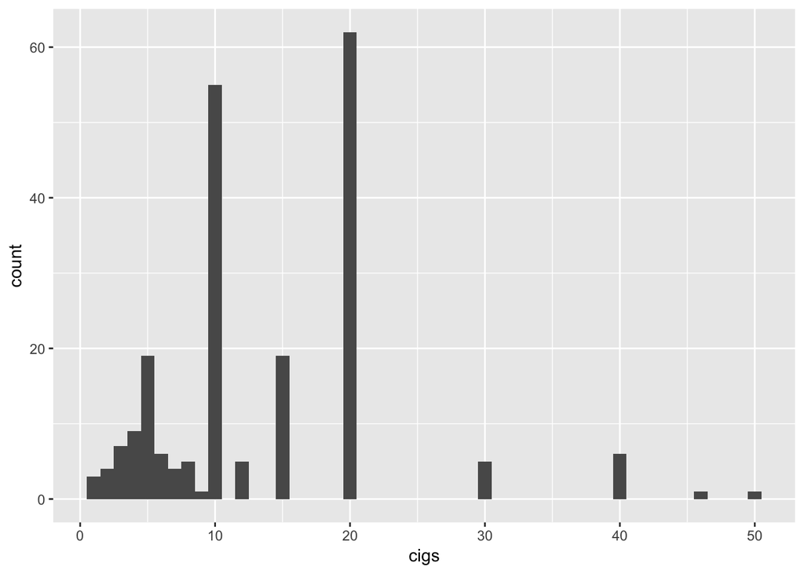

- Average number of cigarettes smoked per day (women during pregnancy)

```
##       cigs
##  Min.   : 1.00
##  1st Qu.: 6.00
##  Median :10.00
##  Mean   :12.41
##  3rd Qu.:20.00
##  Max.   :40.00
```

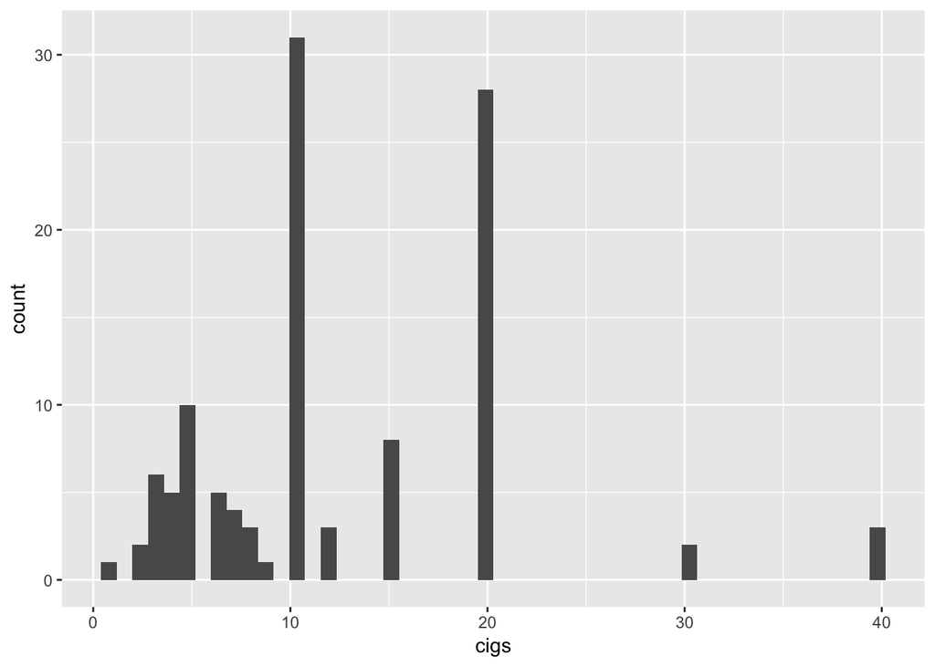

```
## # A tibble: 1 x 1
##       n
##   <int>
## 1   196
```

```
## # A tibble: 1 x 1
##       n
##   <int>
## 1  1192
```

```
## [1] 13.18624
```

```
## [1] 3.071271
```

```
## [1] 0.9180645
```

## 0.3 C3-MEAP00_01

A data.frame with 1692 observations on 9 variables:

- dcode: district code
- bcode: building code
- math4: percent students satisfactory, 4th grade math
- read4: percent students satisfactory, 4th grade reading
- lunch: percent students eligible for free or reduced lunch
- enroll: school enrollment
- exppp: expenditures per pupil: expend/enroll
- lenroll: log(enroll)
- lexppp: log(exppp)